# Titanic Data set

Contains demographics and passenger information from 891 of the 2224 passengers and crew on board the Titanic. You can view a description of this dataset on the Kaggle website, where the data was obtained.

https://www.kaggle.com/c/titanic/data

## Data set exploration

Let's take a look at the data first...

```python
import pandas as pd
import matplotlib.pyplot as plt
import numpy as np
import seaborn as sns

%matplotlib inline


df = pd.read_csv('data/titanic_data.csv')
```

```python
df.head(5)
```

|  | PassengerId | Survived | Pclass | Name | Sex | Age | SibSp | Parch | Ticket | Fare | Cabin | Embarked |
| --- | --- | --- | --- | --- | --- | --- | --- | --- | --- | --- | --- | --- |
| 0 | 1 | 0 | 3 | Braund, Mr. Owen Harris | male | 22 | 1 | 0 | A/5 21171 | 7.2500 | NaN | S |
| 1 | 2 | 1 | 1 | Cumings, Mrs. John Bradley (Florence Briggs Th... | female | 38 | 1 | 0 | PC 17599 | 71.2833 | C85 | C |
| 2 | 3 | 1 | 3 | Heikkinen, Miss. Laina | female | 26 | 0 | 0 | STON/O2. 3101282 | 7.9250 | NaN | S |
| 3 | 4 | 1 | 1 | Futrelle, Mrs. Jacques Heath (Lily May Peel) | female | 35 | 1 | 0 | 113803 | 53.1000 | C123 | S |
| 4 | 5 | 0 | 3 | Allen, Mr. William Henry | male | 35 | 0 | 0 | 373450 | 8.0500 | NaN | S |

```python
df.info()
```

```
<class 'pandas.core.frame.DataFrame'>
Int64Index: 891 entries, 0 to 890
Data columns (total 12 columns):
PassengerId    891 non-null int64
Survived       891 non-null int64
Pclass         891 non-null int64
Name           891 non-null object
Sex            891 non-null object
Age            714 non-null float64
SibSp          891 non-null int64
Parch          891 non-null int64
Ticket         891 non-null object
Fare           891 non-null float64
Cabin          204 non-null object
Embarked       889 non-null object
dtypes: float64(2), int64(5), object(5)
memory usage: 90.5+ KB
```

```python
df.describe()
```

|  | PassengerId | Survived | Pclass | Age | SibSp | Parch | Fare |
| --- | --- | --- | --- | --- | --- | --- | --- |
| count | 891.000000 | 891.000000 | 891.000000 | 714.000000 | 891.000000 | 891.000000 | 891.000000 |
| mean | 446.000000 | 0.383838 | 2.308642 | 29.699118 | 0.523008 | 0.381594 | 32.204208 |
| std | 257.353842 | 0.486592 | 0.836071 | 14.526497 | 1.102743 | 0.806057 | 49.693429 |
| min | 1.000000 | 0.000000 | 1.000000 | 0.420000 | 0.000000 | 0.000000 | 0.000000 |
| 25% | 223.500000 | 0.000000 | 2.000000 | 20.125000 | 0.000000 | 0.000000 | 7.910400 |
| 50% | 446.000000 | 0.000000 | 3.000000 | 28.000000 | 0.000000 | 0.000000 | 14.454200 |
| 75% | 668.500000 | 1.000000 | 3.000000 | 38.000000 | 1.000000 | 0.000000 | 31.000000 |
| max | 891.000000 | 1.000000 | 3.000000 | 80.000000 | 8.000000 | 6.000000 | 512.329200 |

```python
for col in df.columns:
    if df[col].dtype == 'O':
        print " Variable {0} has {1} different values from {2} different entries".format(col,
                                                                                         len(df[df[col].isnull()==0][col].unique()),
                                                                                         len(df[df[col].isnull()==0]))
```

```
 Variable Name has 891 different values from 891 different entries
 Variable Sex has 2 different values from 891 different entries
 Variable Ticket has 681 different values from 891 different entries
 Variable Cabin has 147 different values from 204 different entries
 Variable Embarked has 3 different values from 889 different entries
```

Following observations can be made:

- We have 12 kind of variables for each 891 passenger from the Titanic.
- Some variables are not available for all passengers
- Data types are correct regarding to the kind of information they describe.
- 2 categories of passengers: those who survived (Survived = 1) and those who did not (Survived = 0)
- 3 categories of passenger class
- Age ranging from 0.42 (less than 1 year old?) to 80 years old
- Siblings and spouse count ranging from 0 to 8 (large family...)
- Parent and children count ranging from 0 to 6
- Fare ranging from 0 (crew?) to 512.3
- There are only 204 entries for the Cabin variable
- Passengers embarked from 3 different ports

## Question

Following our first observations about the data sets, the main question we will study in the following paragraphs is:

- What factors made people **more likely to survive?**

In that case, the **Survived** column would be our dependent variable, whereas the 11 others would be our independent variables.

## Data Analysis

### Survival rate per variable

Let's compare the survival rate per variable, splited between its different main categories.

#### Function to plot automatically the survival rate per category for one variable

```python
df2 = 0
df2 = df.copy() # Copy df dataframe in order to keep an 'untouched' Dataframe

def barplot_survival_rate(col, legend, xlabels = None):
    if xlabels== None:
        xlabels = df2.groupby(col)['Survived'].mean().keys()
    values = df2.groupby(col)['Survived'].mean()
    N = len(values)
    ind = np.arange(N)
    width = 0.4

    plt.bar(ind, values, width, label=legend)
    plt.axhline(df2.Survived.mean(), color = 'r', ls = '--', label='mean survival rate')
    plt.legend()

    plt.ylabel('Survival rate')
    plt.title(col)
    plt.xticks(ind + width/2., xlabels)
    plt.yticks(np.arange(0, 1.1, 0.1))
    plt.show()
```

#### Gender

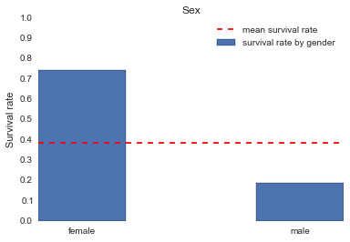

```python
barplot_survival_rate('Sex', 'survival rate by gender')
```

#### Passenger class

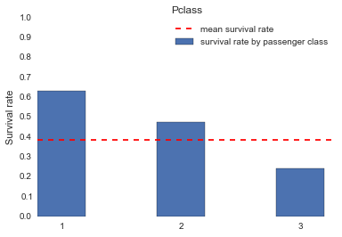

```python
barplot_survival_rate('Pclass', 'survival rate by passenger class')
```

#### Count of siblings and spouse

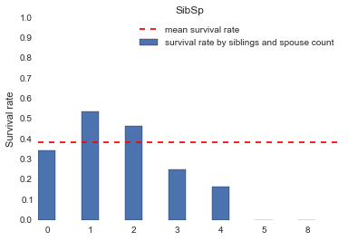

```python
barplot_survival_rate('SibSp', 'survival rate by siblings and spouse count')
```

#### Count of parent and child

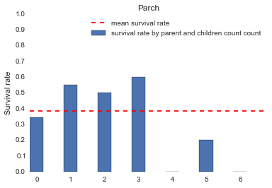

```python
barplot_survival_rate('Parch', 'survival rate by parent and children count count')
```

#### Total family members (parent, children, siblings, spouse)

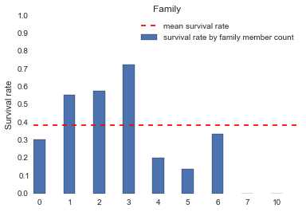

```
Family
0         537
1         161
2         102
3          29
4          15
5          22
6          12
7           6
10          7
Name: Survived, dtype: int64
```

```python
df2['Family'] = df2.Parch + df2.SibSp
barplot_survival_rate('Family', 'survival rate by family member count')

print df2.groupby('Family')['Survived'].count()
```

#### Port origin

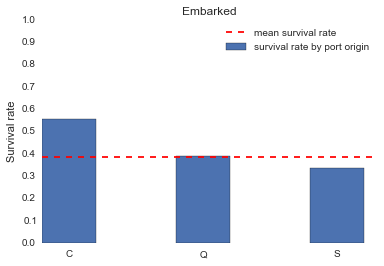

```
Passenger split between each port:
Embarked
C           168
Q            77
S           644
Name: Survived, dtype: int64
```

```python
barplot_survival_rate('Embarked', 'survival rate by port origin')
print 'Passenger split between each port:'
print df2.groupby(['Embarked'])['Survived'].count()
```

The previous results are quite unexpected. I would have thought that port origin did not affect the survival rate. Let's dig deeper into the data...

#### Analyze - Do people coming from Cherbourg are from a higher class (i.e. closer to 1) ?

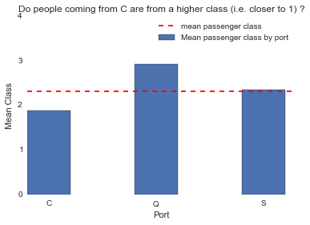

```python
## bar plot ##
title = 'Do people coming from C are from a higher class (i.e. closer to 1) ?'
values = df2.groupby('Embarked')['Pclass'].mean()
xlabels = values.keys()
legend = 'Mean passenger class by port'
N = len(values)
ind = np.arange(N)
width = 0.4

plt.bar(ind, values, width, label=legend)
plt.axhline(df2.Pclass.mean(), color = 'r', ls = '--', label='mean passenger class')
plt.legend()

plt.ylabel('Mean Class')
plt.xlabel('Port')
plt.title(title)
plt.xticks(ind + width/2., xlabels)
plt.yticks(np.arange(0, 5, 1))
plt.show()
```

#### Analyze - Do people coming from C have more women ?

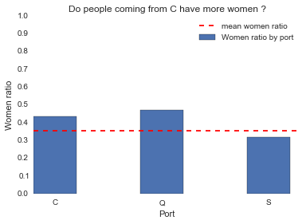

```python
## replace categories by 1s and 0s ##
df3 = df2.copy()
df3.Sex.replace(to_replace='male', value=1, inplace=True)
df3.Sex.replace(to_replace='female', value=0, inplace=True)

## bar plot ##
title = 'Do people coming from C have more women ?'
values = 1-df3.groupby(['Embarked'])['Sex'].mean()
xlabels = values.keys()
legend = 'Women ratio by port'
N = len(values)
ind = np.arange(N)
width = 0.4

plt.bar(ind, values, width, label=legend)
plt.axhline(1-df3.Sex.mean(), color = 'r', ls = '--', label='mean women ratio')
plt.legend()

plt.ylabel('Women ratio')
plt.xlabel('Port')
plt.title(title)
plt.xticks(ind + width/2., xlabels)
plt.yticks(np.arange(0, 1.1, .1))
plt.show()
```

#### Fare

For that one (and the Age variable), we need to work a bit on the data to categorize fare and age values into different bins.

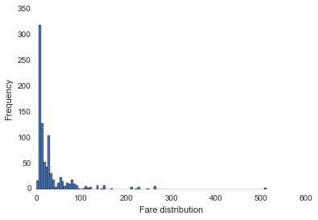

```python
# ploting the distribution to get an idea about the bin size and range
plt.hist(df.Fare.values, bins = 100)
plt.ylabel('Frequency')
plt.xlabel('Fare distribution')
plt.show()
```

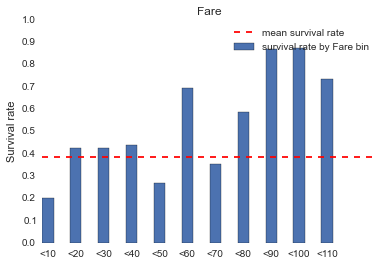

```python
# Replace by upper bin value
fare_bins = np.linspace(0,100,11)
df2.Fare = np.digitize(df2.Fare, fare_bins)

# Plot the bar graph
xlabels = df2.groupby('Fare')['Survived'].mean().keys() * 10
xlabels = map(str, list(xlabels))
xlabels = ['<'+ x  for x in xlabels]
# The labels can be misleading. The bar represent the frequency between x-1 and x.
barplot_survival_rate('Fare', 'survival rate by Fare bin', xlabels)
```

The labels can be misleading. The bar represent the frequency between x-1 and x.

#### Age

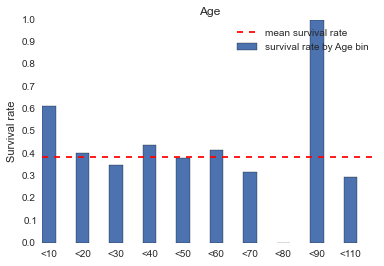

[output not shown]

```python
# Deal with NaN values - warning : this leads to reducing the variance of the sample, which can affect statistical test !
df2.Age.fillna(df2.Age.mean())

# Replace by upper bin value
age_bins = np.linspace(0,100,11)
df2.Age = np.digitize(df2.Age, age_bins)

# Plot the bar graph
xlabels = df2.groupby('Age')['Survived'].mean().keys() * 10
xlabels = map(str, list(xlabels))
xlabels = ['<'+ x  for x in xlabels]
# The labels can be misleading. The bar represent the frequency between x-1 and x.
barplot_survival_rate('Age', 'survival rate by Age bin', xlabels)

print df2.groupby(['Age'])['Survived'].count()
print 'there are only {0} and {1} values for the 2 last bins, which explains the unsignificant results.'\
.format(df2.groupby('Age')['Survived'].count()[8], df2.groupby('Age')['Survived'].count()[9])
```

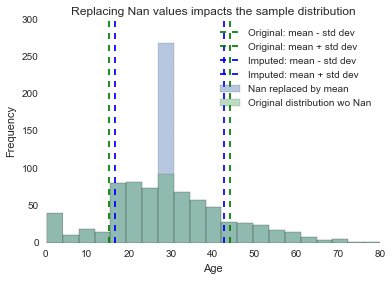

```python
sns.distplot(df.Age.fillna(df.Age.mean()), bins = 21, kde = False, label='Nan replaced by mean')
sns.distplot(df.Age.dropna(), bins = 21, kde = False, label='Original distribution wo Nan')
plt.axvline(df.Age.dropna().mean()-df.Age.dropna().std(), color = 'g', ls = '--', label='Original: mean - std dev ')
plt.axvline(df.Age.dropna().mean()+df.Age.dropna().std(), color = 'g', ls = '--', label='Original: mean + std dev ')
plt.axvline(df.Age.fillna(df.Age.mean()).mean()-df.Age.fillna(df.Age.mean()).std(), color = 'b', ls = '--', label='Imputed: mean - std dev ')
plt.axvline(df.Age.fillna(df.Age.mean()).mean()+df.Age.fillna(df.Age.mean()).std(), color = 'b', ls = '--', label='Imputed: mean + std dev ')
plt.legend()
plt.ylabel('Frequency')
plt.title('Replacing Nan values impacts the sample distribution')
plt.show()
```

As we can see, replacing the Nan values by the sample mean reduces its variance. This can cause issues if we are planning on applying statistical tests.

#### Cabin

```
there are 687 missing entries out of 891 total entries for the Cabin column
```

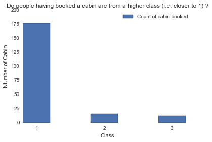

```python
# How many missing entries ?
print 'there are {0} missing entries out of {1} total entries for the Cabin column'.format(len(df3.Cabin) - df3.Cabin.count(),
                                                                                           len(df3.Cabin))
# Plot the bar graph
title = 'Do people having booked a cabin are from a higher class (i.e. closer to 1) ?'
values = df3[['Cabin', 'Pclass']][df3.Cabin.notnull()].groupby(['Pclass']).count()
xlabels = values.index
legend = 'Count of cabin booked'
N = len(values)
ind = np.arange(N)
width = 0.4

plt.bar(ind, values.values, width, label=legend)
plt.legend()
plt.ylabel('NUmber of Cabin')
plt.xlabel('Class')
plt.title(title)
plt.xticks(ind + width/2., xlabels)
plt.yticks(np.arange(0, 225, 25))
plt.show()
```

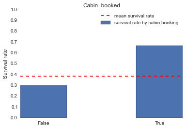

```python
df2['Cabin_booked'] = df2['Cabin'].notnull()
barplot_survival_rate('Cabin_booked', 'survival rate by cabin booking')
```

#### Displaying the numerical values

```python
for col in ['Sex', 'Embarked', 'Pclass', 'SibSp', 'Parch', 'Fare', 'Age', 'Cabin_booked', 'Family']:
    print df2.groupby(col)['Survived'].mean()
    print '\n'
```

```
Sex
female    0.742038
male      0.188908
Name: Survived, dtype: float64


Embarked
C           0.553571
Q           0.389610
S           0.336957
Name: Survived, dtype: float64


Pclass
1         0.629630
2         0.472826
3         0.242363
Name: Survived, dtype: float64


SibSp
0        0.345395
1        0.535885
2        0.464286
3        0.250000
4        0.166667
5        0.000000
8        0.000000
Name: Survived, dtype: float64


Parch
0        0.343658
1        0.550847
2        0.500000
3        0.600000
4        0.000000
5        0.200000
6        0.000000
Name: Survived, dtype: float64
```

[output cut: 33 more lines]

```
True            0.666667
Name: Survived, dtype: float64


Family
0         0.303538
1         0.552795
2         0.578431
3         0.724138
4         0.200000
5         0.136364
6         0.333333
7         0.000000
10        0.000000
Name: Survived, dtype: float64
```

## Conclusions

### Gender

With **74% of the women having survived the disaster**, compared to only 19% for men, **gender show a great correlation with survival rate**. The causation cannot be derived here, but a reasonable guess could be that during that disaster, women were put first in the lifeboats.

### Passenger class

With **63% of the first class passengers having survived the disaster** (compared to 47% for second class passengers, and 24% for third class passengers), passenger class is also a variable showing a strong correlation with survival rate: **the higher the class, the higher the chances to survive**.

A logical explanation for this correlation could be that passenger from the upper class tended to be on the ship upper levels, which puts them closer to the lifeboats.

### Age

**The first bin (age < 10 years) shows a significantly higher survival rate (61%)**. It can be guessed that children and babies were more inclined to be helped and protected during the catastrophe.

### Siblings and spouse count / Parent and children count

The trend is less obvious here. It seems that **lone passengers where less probable** to survive (30% survival rate) than passenger coming with family members. This appears at least if we are talking about 2 to 4 people groups.

Groups with higher family member counts seem to be associated with lower survival rates (under 34%). But the **data for these big groups is scarce**, which makes it difficult to justify the correlation.

### Fare

Ticket price is logically associated with class level. Hence, as for the Passenger class variable, we can see a clear correlation between Fare and survival rate. **The higher the price, the higher the survival rate**.

### Cabin

There are a lot of **missing entries** for this variable. These entries are strings which represent cabin number. It could be interesting to see the dependency between the location of the cabin and the survival rate. But without the titanic map, it is difficult to assess the cabin locations.

Hence, I only focused here on the relationship between cabin booking, and passenger class. As it could have been guessed, the cabin were mainly booked by first class passenger (86%), which explains the very **high correlation between 'having booked a cabin' and 'having survived to the disaster'** (67% survival rate).

It can be guessed that people having booked a cabin where on the upper levels of the boat, which must have helped to jump into a lifeboat.

### Port

According to the data, **people coming from Cherbourg showed a higher survival rate than the others** (55%), which was a bit unexpected.

But after digging a bit the question, it appears that **the passengers from Cherbourg were essentially from class 1 and 2**, which, as we saw before, was **correlated with a high survival rate**. This helps to explain this unexpected result concerning the Embarked variable.

I also tried to figure out whether there were more women coming from Cherbourg. We can see indeed a women ratio slightly higher than for people coming from Southampton, which goes in the direction of the correlation that we saw before.

### Limitations

Also, all the previous remarks on the possible correlation between the different variables were based on statistical calculation, but not on statistical testing. To validate these conclusion, additional testing should be pursued.

### Summary

Through this analysis, we were able to observe different correlation between survival rate and the other variable. In particular, **being a woman** seemed to be correlated with a higher survival rate (74%) than when being a man (19%). Age seemed also to be an important factor, but only for **kids** (age < 10 years) who showed a survival rate higher than the mean (61% against 38%). Last but not least, **passenger from higher** class (1 and 2) showed also higher survival rate (resp. 63% and 47%).

But it is important to underline that these observations were not validated by **statistical testing**, which could be an opportunity to extend the analysis further on.

## Source :

Titanic dataset : https://www.kaggle.com/c/titanic/data

pyplot examples : http://matplotlib.org/api/pyplot_api.html

bining data : http://stackoverflow.com/questions/6163334/binning-data-in-python-with-scipy-numpy